# Extended Morphology Models

7.18.19

## Fossil Ants

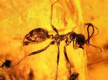

Steve Shattuck

## Fossil Ants

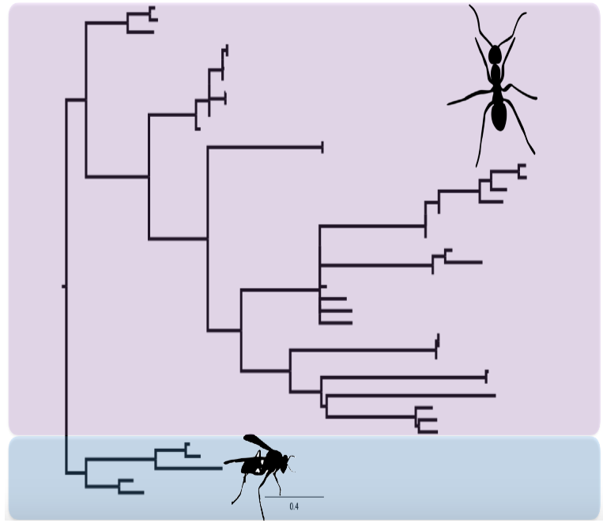

## Fossil Ants

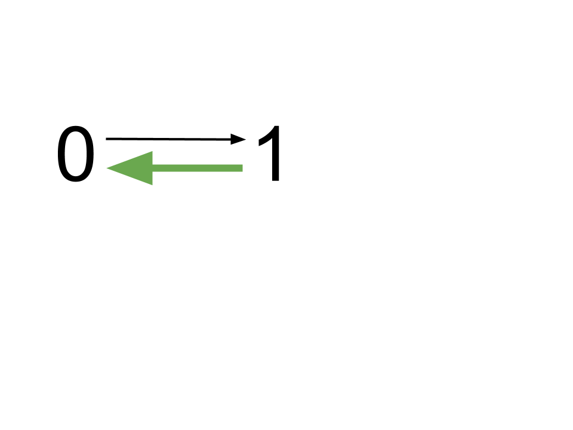

## Fossil Ants

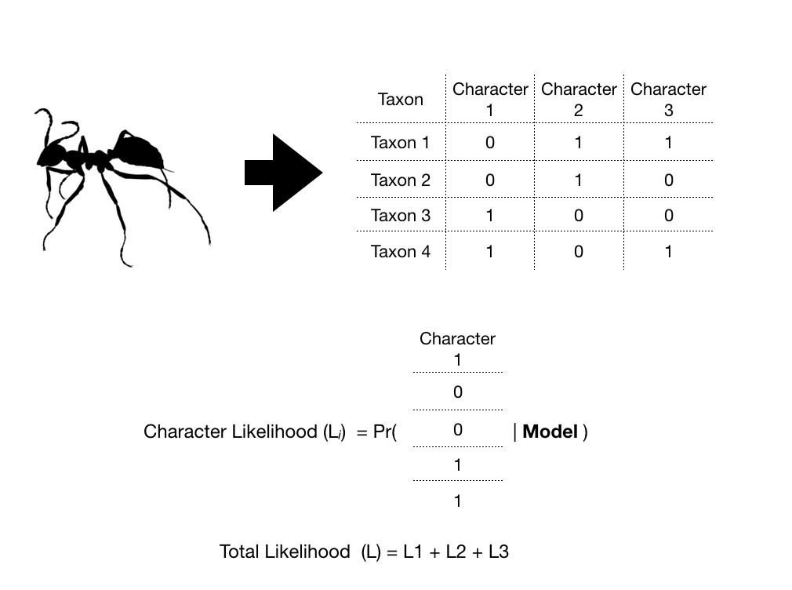

## State Frequenies

\[Q_{JC69} = \begin{pmatrix} {*} & \frac{1}{3} & \frac{1}{3} & \frac{1}{3} \\ \frac{1}{3} & {*} & \frac{1}{3} & \frac{1}{3} \\ \frac{1}{3} & \frac{1}{3} & {*} & \frac{1}{3} \\ \frac{1}{3} & \frac{1}{3} & \frac{1}{3} & {*} \end{pmatrix} \mbox{ ,}\]

## State Frequenies

\[Q = \begin{pmatrix} -(k-1)\mu & \mu & \mu & \mu \\ \mu & -(k-1)\mu & \mu & \mu \\ \mu & \mu & -(k-1)\mu & \mu \\ \mu & \mu & \mu & -(k-1)\mu \\ \end{pmatrix} \mbox{ ,}\]

Pr(01) = Rate at which we expect 0->1 * probability of 0

## State Frequenies

\[Q = \begin{pmatrix} -(k-1)\mu & \mu\pi & \mu\pi & \mu\pi \\ \mu\pi_{1} & -(k-1)\mu & \mu\pi_{1} & \mu\pi_{1} \\ \mu\pi_{2} & \mu\pi_{2} & -(k-1)\mu & \mu\pi_{2} \\ \mu_{3} & \mu\pi_{3} & \mu_{3} & -(k-1)\mu \\ \end{pmatrix} \mbox{ ,}\]

Pr(01) = Rate at which we expect 0->1 * probability of 0  
Pr(01) = .75 * .5  
Pr(01) = 0.375

## A Prior On State Frequenies

But … maybe every character in the dataset does not have the same equilibrium character frequency

## A Prior On State Frequencies

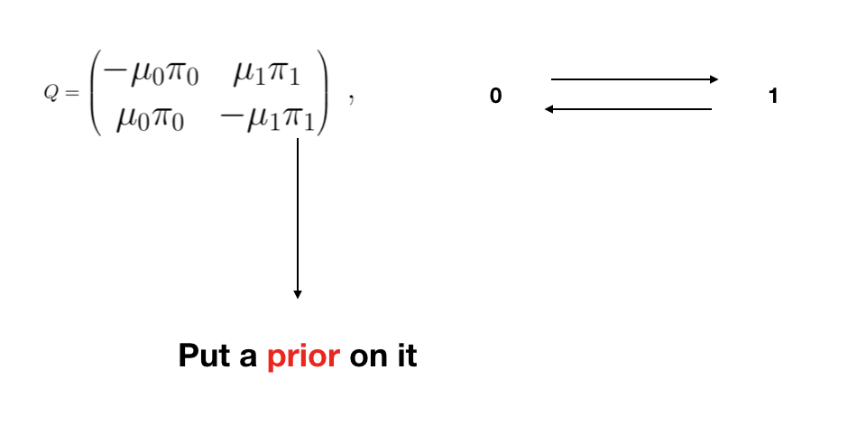

## A Prior On State Frequencies

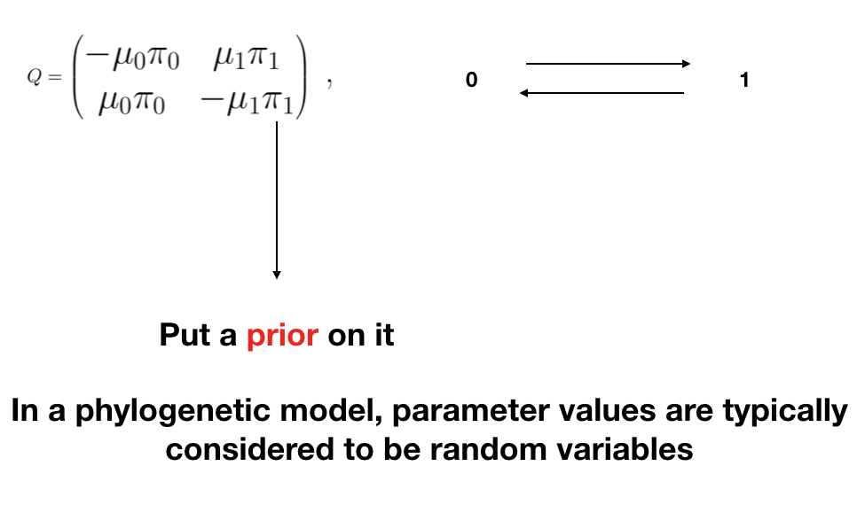

## A Prior On State Frequencies

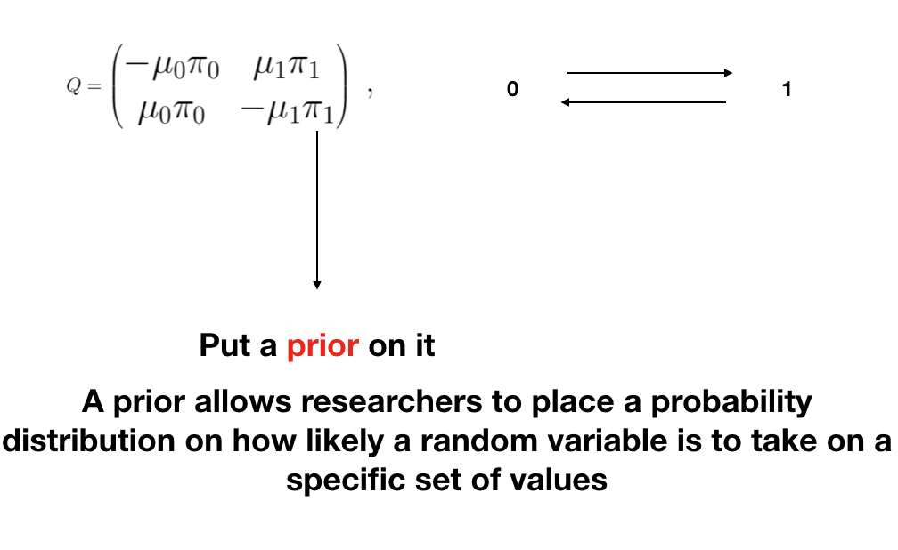

## A Prior On State Frequenies

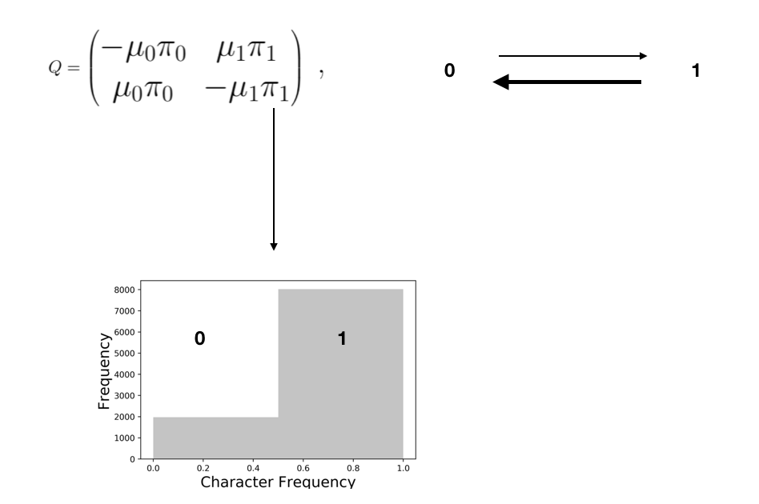

## A Prior On State Frequenies

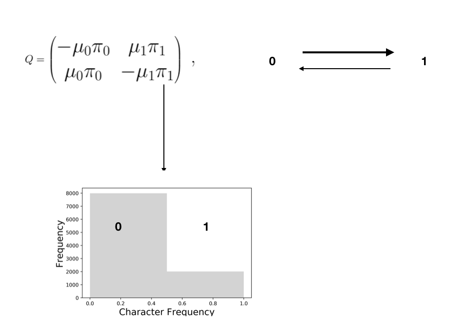

## A Prior On State Frequencies

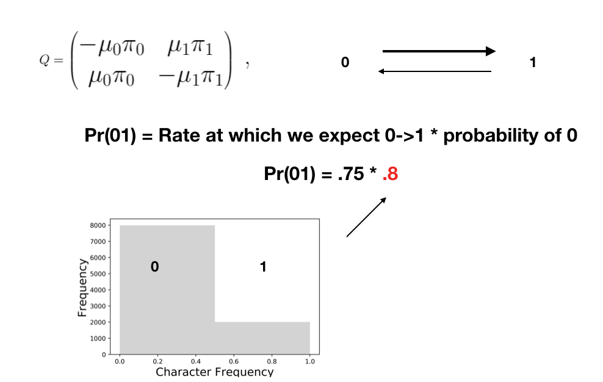

## A Prior On State Frequencies

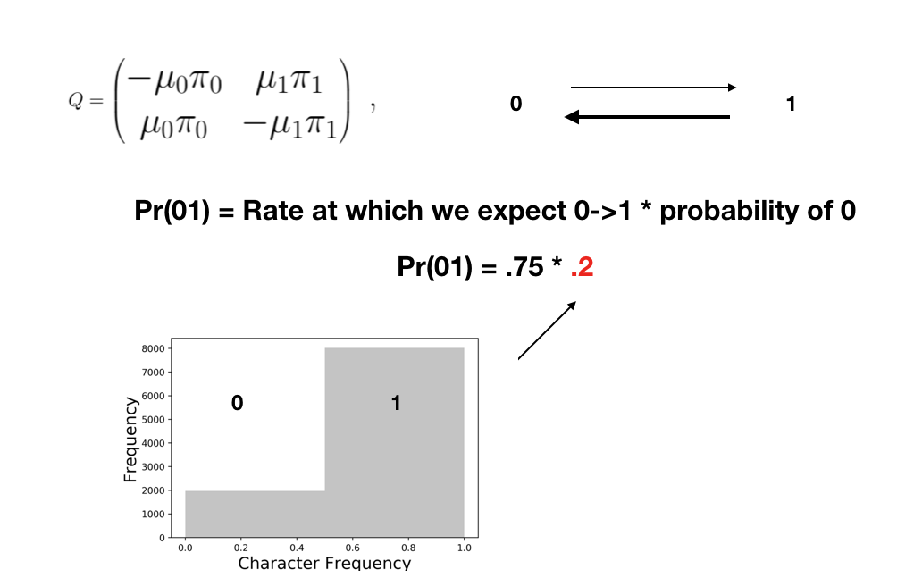

## The Symmetric Beta

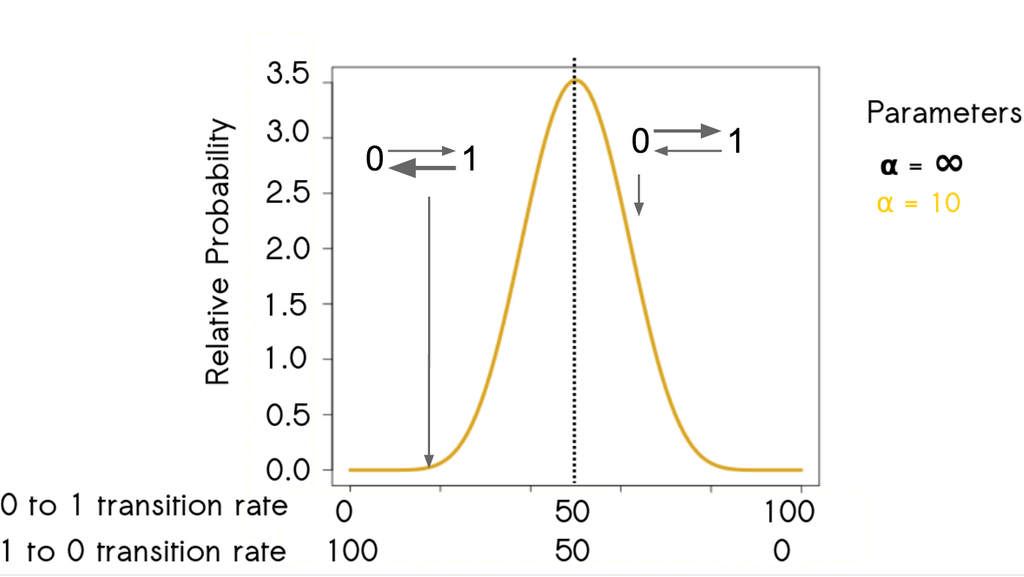

## The Symmetric Beta

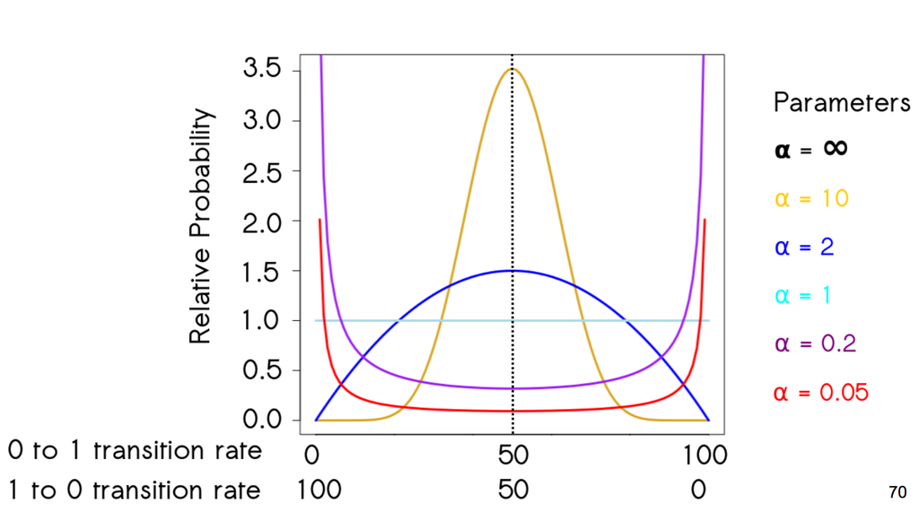

## The Beta Model

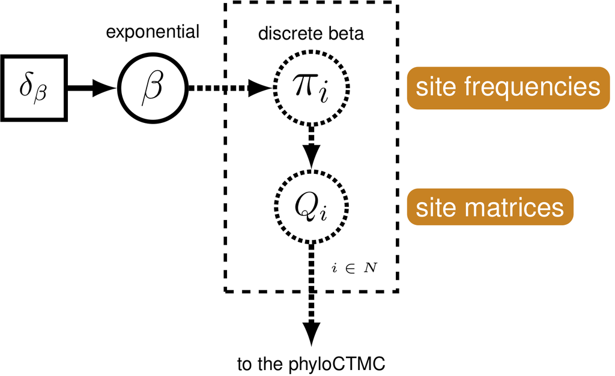

## The Symmetric Beta

\(\alpha\) = \(\beta\)

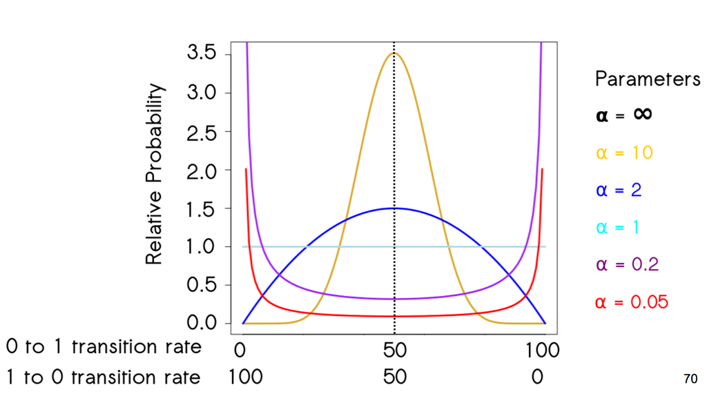

## Site Heterogeneous Discrete Morphology Model

\(\alpha\) != \(\beta\)

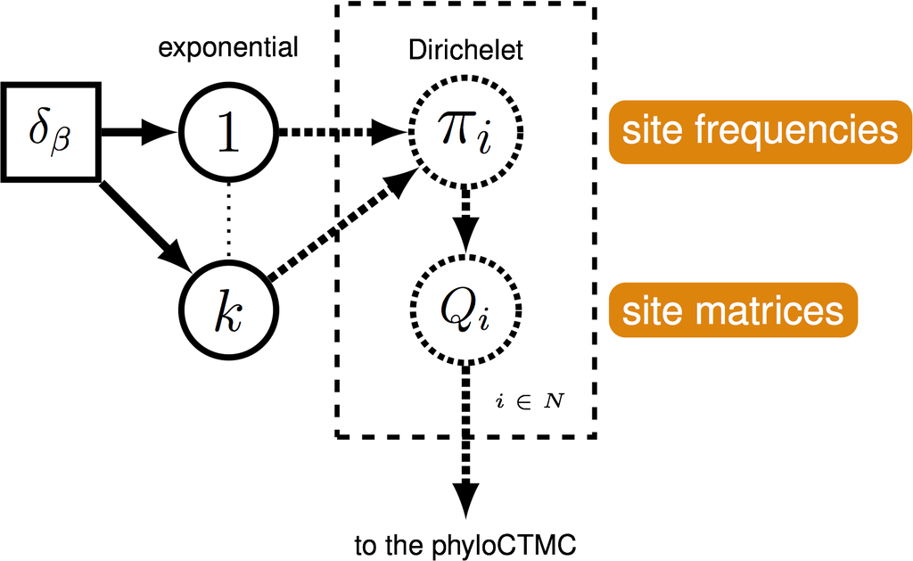

## Does it matter?

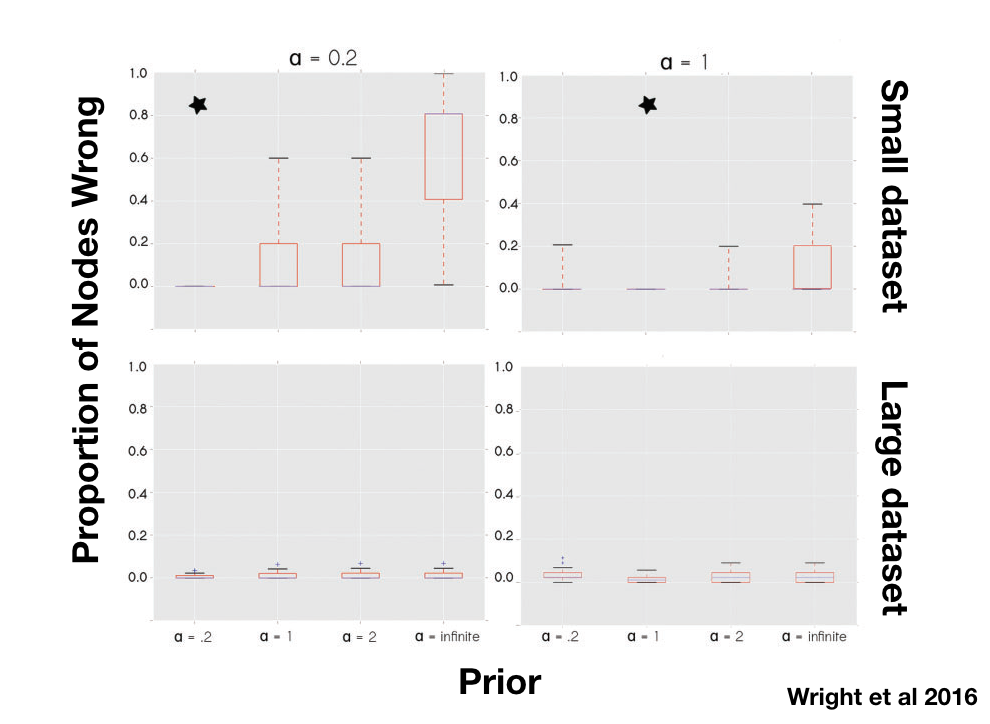

## Does it matter?

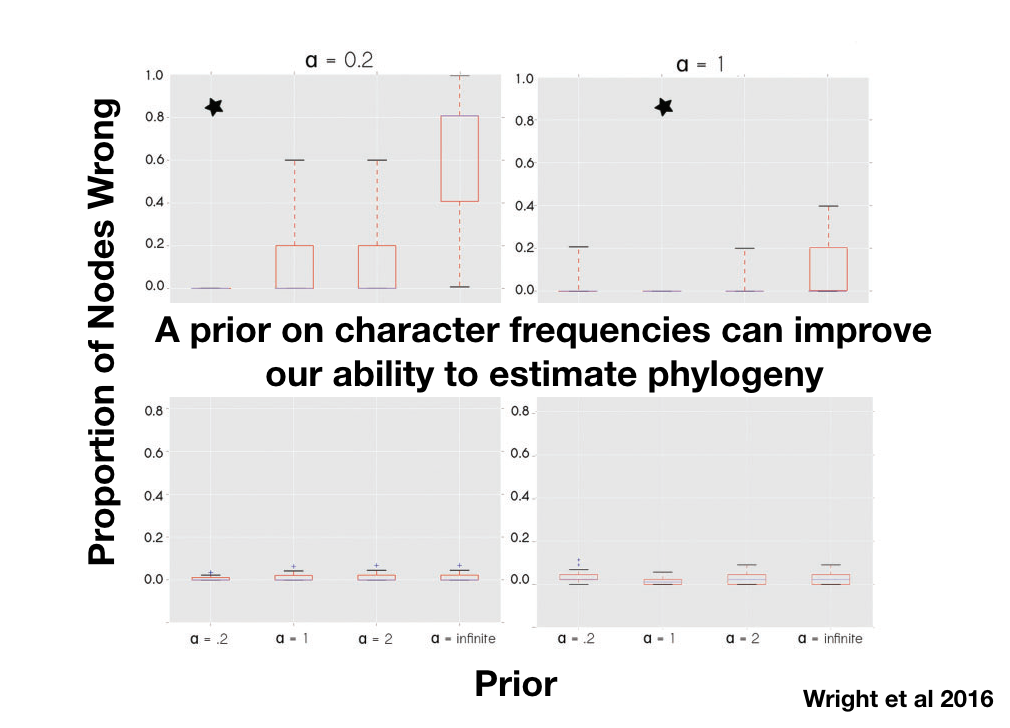

## Does it matter?

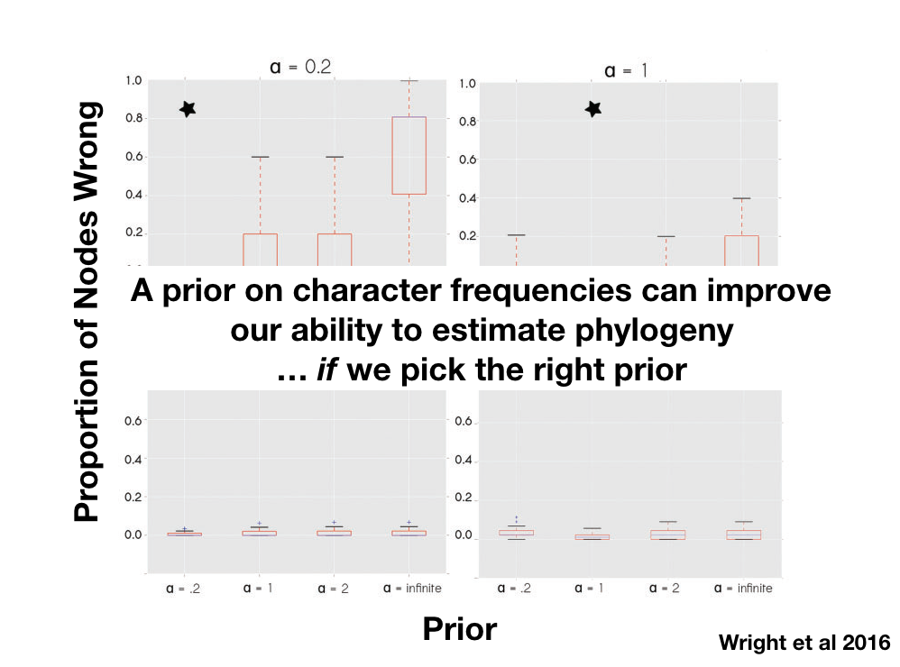

## Does it matter?

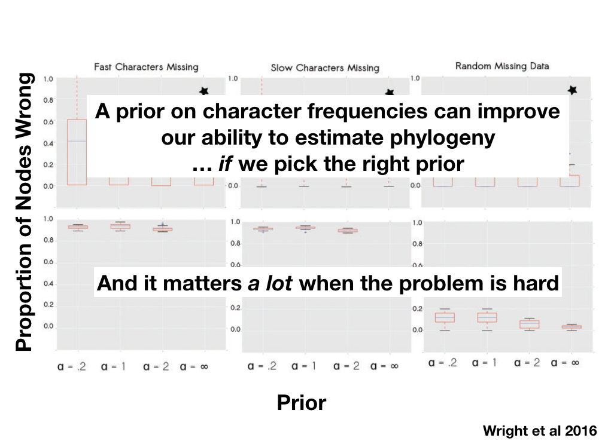